# A3: SPL Library Checkouts

### Second Trends Over Time Chart

I included this chart to visualize the popularity of each Harry Potter book over time. The chart shows the total number of checkouts for each book from 2017 to 2023, which is useful for libraries or booksellers who want to understand which books are still in demand.

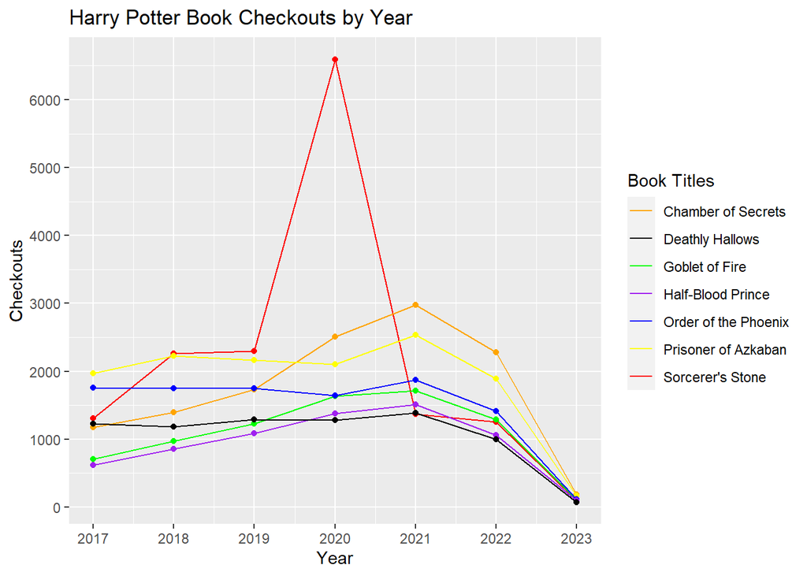

### Third Trends by Material Type

This bar chart gains insights into the top 6 material types that have the highest total checkouts from 2017-2023. It’s specifically top 6 because 7 and onwards’ numbers are too small and insignificant in relation. The chart shows that books are the most checked out material type, followed by ebooks, audiobooks, and DVDs. Magazines and music CDs have the lowest total checkouts among the top 6 materials.

The patterns that emerged from this chart are that books and ebooks are the most popular material types among library patrons, which could be due to their accessibility and convenience. It’s also interesting to note that audiobooks have a high total checkout rate, which suggests that patrons may be utilizing them for their convenience and portability. DVDs, on the other hand, have a lower total checkout rate compared to books and ebooks, which could be attributed to the rise of online streaming services.

Overall, this chart provides valuable insights into the most popular material types among library patrons, which can help inform decisions on library collection development and resource allocation.

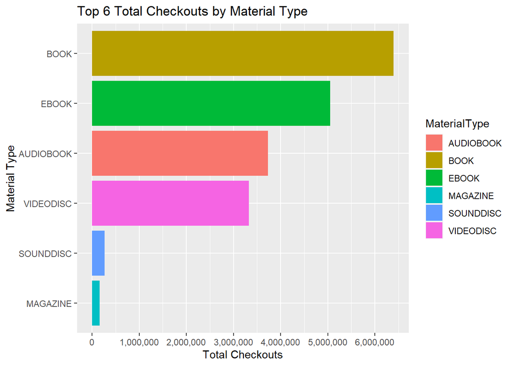